# Notebook 20 – Solutions

### Application: French COVID-19 Data

Today, let’s look at an application using data from the COVID-19 pandemic in France. We’ll see some more pandemic data in the coming weeks. Today we will use several data sets. Load them in below and take a moment to look at them.

```r
covid <- read_csv("data/france_departement_covid.csv")
pop <- read_csv("data/france_departement_population.csv")
cities <- read_csv("data/france_cities.csv")
geo_fr <- read_sf("data/france_departement.geojson") %>%
  filter(departement <= "95")
```

To get started, produce a basic spatial plot of the `geo_fr` data:

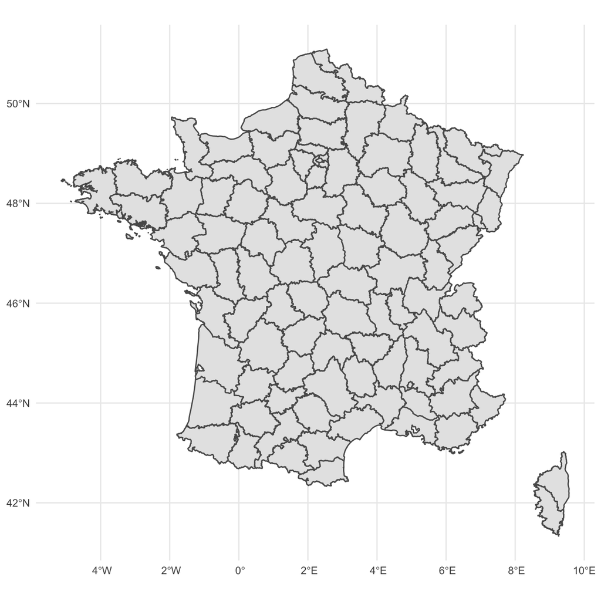

```r
geo_fr %>%
  ggplot() +
    geom_sf()
```

Now, filter the dataset `covid` to the date “2020-05-01” and left join it into the `geo_fr` dataset by the key “departement”. Just have the data print out to the notebook.

```r
covid %>%
  filter(date == "2020-05-01") %>%
  left_join(geo_fr, by = "departement")
```

```
## # A tibble: 101 × 11
##    date       departement departement_name… deceased hospitalised reanimation
##    <date>     <chr>       <chr>                <dbl>        <dbl>       <dbl>
##  1 2020-05-01 01          Ain                     81          158          13
##  2 2020-05-01 02          Aisne                  211          278          37
##  3 2020-05-01 03          Allier                  27           43          14
##  4 2020-05-01 04          Alpes-de-Haute-P…        8           25           2
##  5 2020-05-01 05          Hautes-Alpes             8           36           6
##  6 2020-05-01 06          Alpes-Maritimes        135          219          43
##  7 2020-05-01 07          Ardèche                 68          146          11
##  8 2020-05-01 08          Ardennes                39           46           7
##  9 2020-05-01 09          Ariège                   2            7           1
## 10 2020-05-01 10          Aube                   112          221          10
## # … with 91 more rows, and 5 more variables: recovered <dbl>,
## #   hospitalised_new <dbl>, reanimation_new <dbl>, departement_name.y <chr>,
## #   geometry <MULTIPOLYGON [°]>
```

Now, starting with the code that you created above, plot a map of the French Département according to the the number of people that were hospitalized on 1 May 2020. Use `scale_fill_distiller` to pick a good color scale.

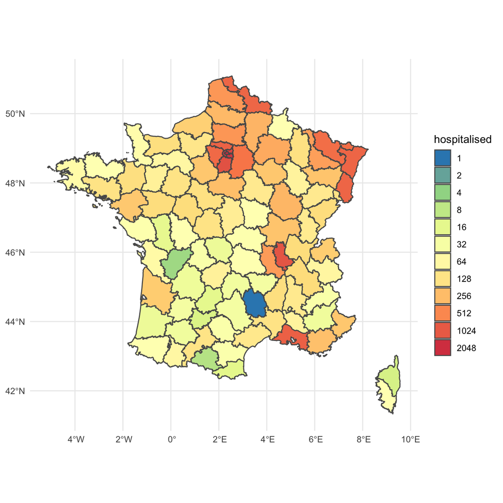

```r
covid %>%
  filter(date == "2020-05-01") %>%
  left_join(geo_fr, by = "departement") %>%
  st_as_sf() %>%
  ggplot() +
    geom_sf(aes(fill = hospitalised)) +
    scale_fill_distiller(
      trans = "log2", palette = "Spectral", guide = "legend", n.breaks = 10
    )
```

A problem with the above map is that it is not normalized by population. Adapt the code above in the block below by joining in the `pop` dataset and instead plotting the hospitalization rate were 100k people.

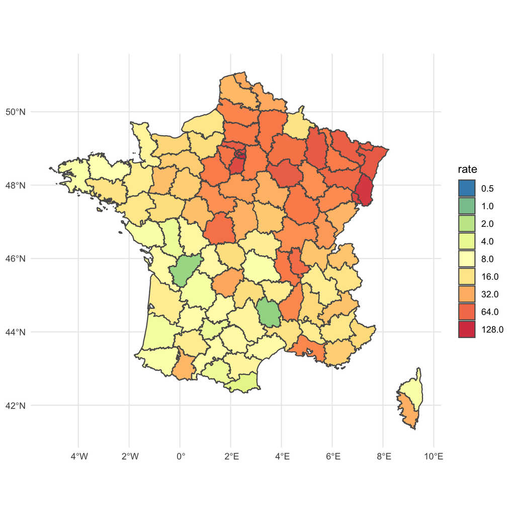

```r
covid %>%
  filter(date == "2020-05-01") %>%
  left_join(geo_fr, by = "departement") %>%
  left_join(pop, by = "departement") %>%
  mutate(rate = hospitalised / population * 100000) %>%
  st_as_sf() %>%
  ggplot() +
    geom_sf(aes(fill = rate)) +
    scale_fill_distiller(
      trans = "log2", palette = "Spectral", guide = "legend", n.breaks = 10
    )
```

We also have a data set of French cities called `cities`. Create a spatial points version of the cities data and save it as an object called `cities_geo`.

```r
cities_geo <- cities %>%
  st_as_sf(coords = c("lon", "lat"), crs = 4326, remove = FALSE)
```

Now, put together the hopsitalization rate map with the cities data in a single plot. Include both points and text labels for the cities.

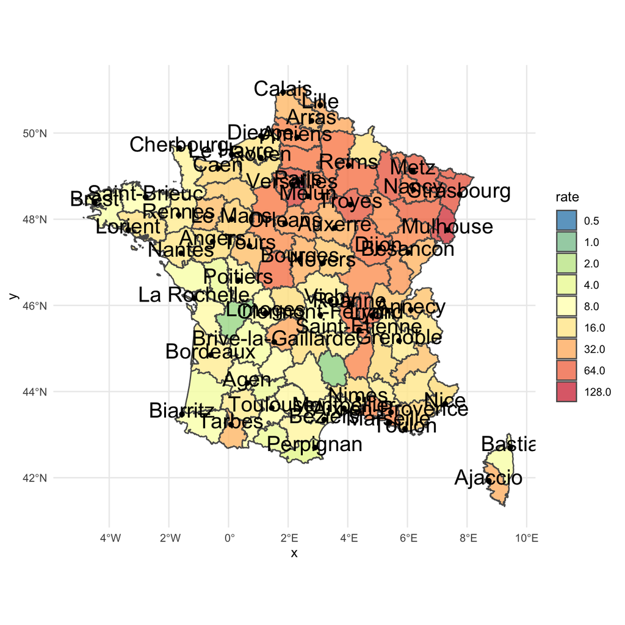

```r
covid %>%
  filter(date == "2020-05-01") %>%
  left_join(geo_fr, by = "departement") %>%
  left_join(pop, by = "departement") %>%
  mutate(rate = hospitalised / population * 100000) %>%
  st_as_sf() %>%
  ggplot() +
    geom_sf(aes(fill = rate), alpha = 0.8) +
    geom_sf(data = cities_geo) +
    geom_sf_text(aes(label = city), data = cities_geo, nudge_y = 0.1, size = 6) +
    scale_fill_distiller(
      trans = "log2", palette = "Spectral", guide = "legend", n.breaks = 10
    )
```

### Application: World Cities

Next, let’s load a data set of world cities. This has a large number of cities and only includes the name, latitude, and longitude.

```r
world <- read_csv("data/world_cities.csv")
world
```

```
## # A tibble: 128,769 × 3
##    name                  lat   lon
##    <chr>               <dbl> <dbl>
##  1 Sant Julià de Lòria  42.5  1.49
##  2 Pas de la Casa       42.5  1.73
##  3 Ordino               42.6  1.53
##  4 les Escaldes         42.5  1.53
##  5 la Massana           42.5  1.51
##  6 Encamp               42.5  1.58
##  7 Canillo              42.6  1.60
##  8 Arinsal              42.6  1.48
##  9 Andorra la Vella     42.5  1.52
## 10 Umm al Qaywayn       25.6 55.6
## # … with 128,759 more rows
```

Create a new version of the world cities data called `world_geo` by converting it into a spatial points data set:

```r
world_geo <- world %>%
  st_as_sf(coords = c("lon", "lat"), crs = 4326, remove = FALSE)
```

Perform a spatial join of `world_geo` with `geo_fr`. Just look at the results of the table without plotting it.

```r
world_geo %>%
  spatial_join(geo_fr)
```

```
## Simple feature collection with 128769 features and 5 fields
## Geometry type: POINT
## Dimension:     XY
## Bounding box:  xmin: -179.122 ymin: -77.846 xmax: 179.3645 ymax: 78.22334
## Geodetic CRS:  WGS 84
## # A tibble: 128,769 × 6
##    name            lat   lon            geometry departement departement_name
##    <chr>         <dbl> <dbl>         <POINT [°]> <chr>       <chr>
##  1 Sant Julià d…  42.5  1.49  (1.49129 42.46372) <NA>        <NA>
##  2 Pas de la Ca…  42.5  1.73  (1.73361 42.54277) <NA>        <NA>
##  3 Ordino         42.6  1.53  (1.53319 42.55623) <NA>        <NA>
##  4 les Escaldes   42.5  1.53  (1.53414 42.50729) <NA>        <NA>
##  5 la Massana     42.5  1.51  (1.51483 42.54499) <NA>        <NA>
##  6 Encamp         42.5  1.58  (1.58014 42.53474) <NA>        <NA>
##  7 Canillo        42.6  1.60   (1.59756 42.5676) <NA>        <NA>
##  8 Arinsal        42.6  1.48  (1.48453 42.57205) <NA>        <NA>
##  9 Andorra la V…  42.5  1.52  (1.52109 42.50779) <NA>        <NA>
## 10 Umm al Qaywa…  25.6 55.6  (55.55517 25.56473) <NA>        <NA>
## # … with 128,759 more rows
```

Notice above that many of the cities are not in France and therefore do not match anything in `geo_fr`. To remove these, add the option `left = FALSE` to the function `spatial_join`:

```r
world_geo %>%
  spatial_join(geo_fr, left = FALSE)
```

```
## Simple feature collection with 8827 features and 5 fields
## Geometry type: POINT
## Dimension:     XY
## Bounding box:  xmin: -4.77086 ymin: 41.3874 xmax: 9.52242 ymax: 51.07786
## Geodetic CRS:  WGS 84
## # A tibble: 8,827 × 6
##    name           lat    lon            geometry departement departement_name
##    <chr>        <dbl>  <dbl>         <POINT [°]> <chr>       <chr>
##  1 Peyrat-le-C…  45.8  1.77   (1.77233 45.81578) 87          Haute-Vienne
##  2 Blaye         45.1 -0.667 (-0.66667 45.13333) 33          Gironde
##  3 Zuydcoote     51.1  2.49   (2.49338 51.06096) 59          Nord
##  4 Zutkerque     50.9  2.07   (2.06818 50.85303) 62          Pas-de-Calais
##  5 Zonza         41.7  9.17   (9.17102 41.74813) 2A          Corse-du-Sud
##  6 Zimmersheim   47.7  7.39   (7.38819 47.72021) 68          Haut-Rhin
##  7 Zillisheim    47.7  7.30   (7.29516 47.69562) 68          Haut-Rhin
##  8 Zegerscappel  50.9  2.4        (2.4 50.88333) 59          Nord
##  9 Yzeures-sur…  46.8  0.872  (0.87166 46.78609) 37          Indre-et-Loire
## 10 Yzeure        46.6  3.35   (3.35495 46.56438) 03          Allier
## # … with 8,817 more rows
```

With the data you created in the previous question, plot the French Départment polygons with the cities (don’t include there names; there are too many) plotted on top:

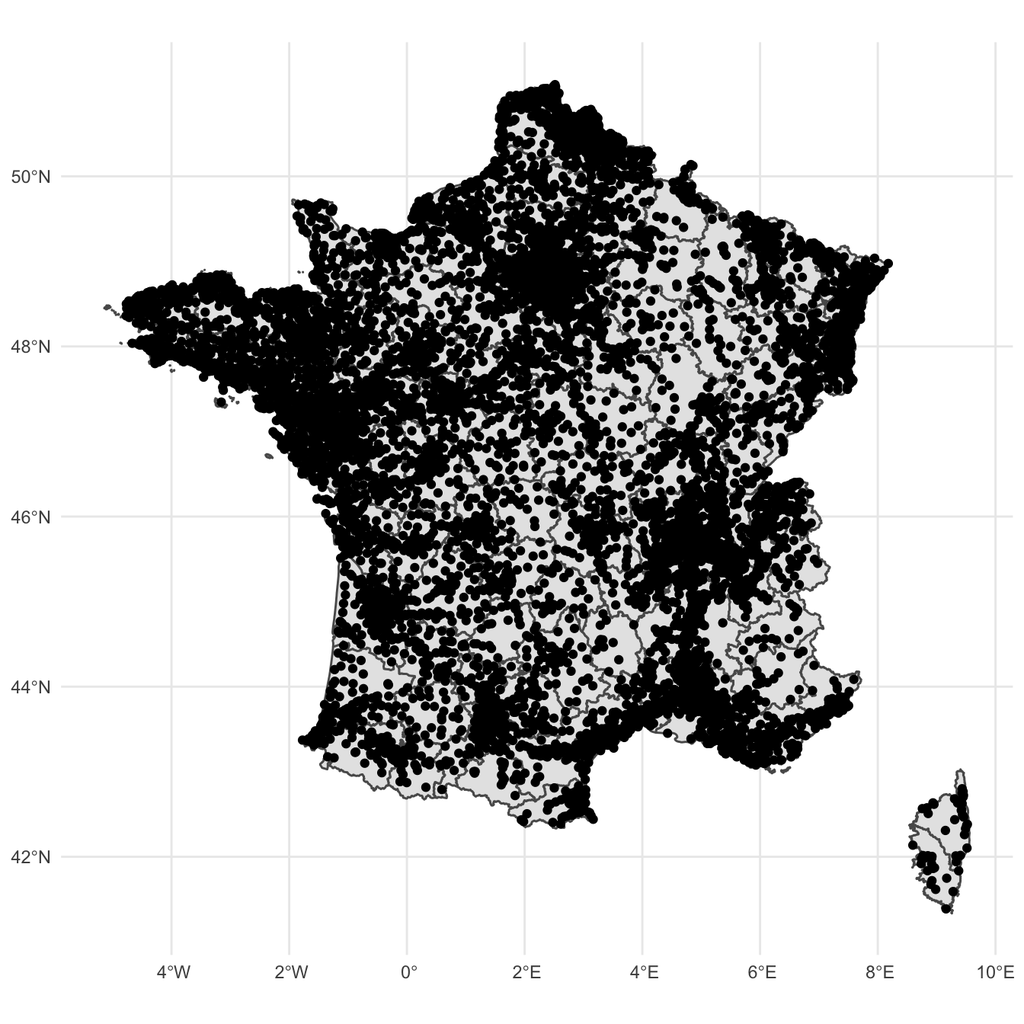

```r
world_geo %>%
  spatial_join(geo_fr, left = FALSE) %>%
  ggplot() +
    geom_sf(data = geo_fr) +
    geom_sf()
```

### US Roads

As a final task, let’s read in the US States data again, renaming one of the variables to make it easier to work with below:

```r
state <- read_sf("data/state.geojson") %>% rename(state = name)
state
```

```
## Simple feature collection with 50 features and 3 fields
## Geometry type: MULTIPOLYGON
## Dimension:     XY
## Bounding box:  xmin: -168.1289 ymin: 18.91747 xmax: -66.9824 ymax: 71.29634
## Geodetic CRS:  WGS 84
## # A tibble: 50 × 4
##    state          abb   fips                                         geometry
##    <chr>          <chr> <chr>                              <MULTIPOLYGON [°]>
##  1 Maine          ME    23    (((-70.70382 43.05983, -70.8268 43.12709, -70.…
##  2 New Hampshire  NH    33    (((-71.50109 45.01338, -71.40564 45.19814, -71…
##  3 Delaware       DE    10    (((-75.7886 39.7222, -75.61724 39.83423, -75.4…
##  4 South Carolina SC    45    (((-83.10861 35.00066, -82.46009 35.17814, -82…
##  5 Nebraska       NE    31    (((-104.0531 43.00059, -102.7921 42.99998, -10…
##  6 Washington     WA    53    (((-117.0324 48.99919, -117.0411 48.1249, -117…
##  7 New Mexico     NM    35    (((-109.0452 36.99908, -108.2494 36.99901, -10…
##  8 South Dakota   SD    46    (((-104.0577 44.99743, -104.0397 45.00055, -10…
##  9 Texas          TX    48    (((-103.0024 36.5004, -102.2505 36.50037, -101…
## 10 California     CA    06    (((-124.2116 41.99846, -123.3476 41.99911, -12…
## # … with 40 more rows
```

```r
hwy <- read_sf("data/usa_roads_95.geojson") %>%
  st_transform(st_crs(state))
hwy
```

```
## Simple feature collection with 525 features and 1 field
## Geometry type: LINESTRING
## Dimension:     XY
## Bounding box:  xmin: -81.77189 ymin: 25.74903 xmax: -67.78124 ymax: 46.14542
## Geodetic CRS:  WGS 84
## # A tibble: 525 × 2
##    name                                                              geometry
##  * <chr>                                                     <LINESTRING [°]>
##  1 I- 295 (-77.29546 37.56063, -77.29528 37.56045, -77.29522 37.56041, -77.2…
##  2 I- 295 (-77.43057 37.65326, -77.42831 37.65292, -77.42785 37.65286, -77.4…
##  3 I- 295 (-77.34648 37.37858, -77.34661 37.38041, -77.34691 37.38475, -77.3…
##  4 I- 295 (-77.29616 37.56033, -77.29618 37.56035, -77.29627 37.56044, -77.2…
##  5 I- 295 (-78.82503 35.14723, -78.82499 35.14723, -78.82465 35.14716, -78.8…
##  6 I- 295 (-77.32988 37.29353, -77.32949 37.29304, -77.32938 37.29287, -77.3…
##  7 I- 295                            (-77.32988 37.29353, -77.33034 37.29413)
##  8 I- 295        (-77.33501 37.31456, -77.33529 37.31392, -77.33567 37.31304)
##  9 I- 295 (-77.33501 37.31456, -77.33496 37.3147, -77.33482 37.31503, -77.33…
## 10 I- 295 (-77.33644 37.30295, -77.33677 37.30356, -77.33691 37.30385, -77.3…
## # … with 515 more rows
```

Create a spatial plot of `hwy`, coloring the lines according to the name of the highway.

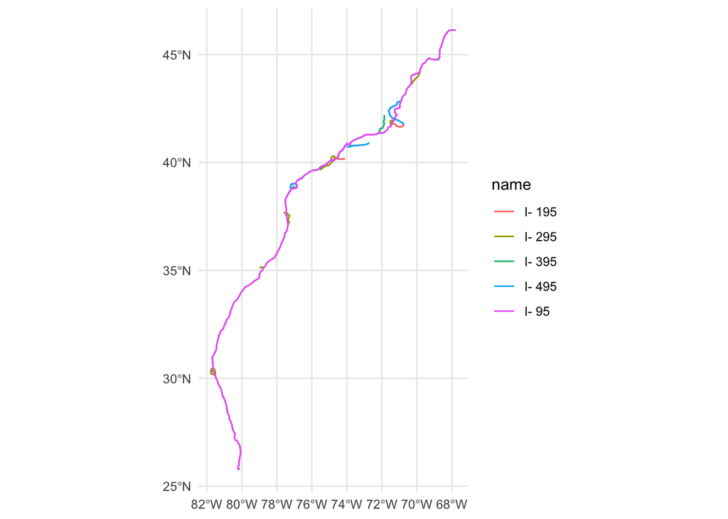

```r
hwy %>%
  ggplot() +
    geom_sf(aes(color = name))
```

Now, perform a spatial join of `hwy` into `state`. Look at the results (do not yet plot them).

```r
hwy %>%
  spatial_join(state)
```

```
## Simple feature collection with 565 features and 4 fields
## Geometry type: LINESTRING
## Dimension:     XY
## Bounding box:  xmin: -81.77189 ymin: 25.74903 xmax: -67.78124 ymax: 46.14542
## Geodetic CRS:  WGS 84
## # A tibble: 565 × 5
##    name                                         geometry state    abb   fips
##    <chr>                                <LINESTRING [°]> <chr>    <chr> <chr>
##  1 I- 295 (-77.29546 37.56063, -77.29528 37.56045, -77.… Virginia VA    51
##  2 I- 295 (-77.43057 37.65326, -77.42831 37.65292, -77.… Virginia VA    51
##  3 I- 295 (-77.34648 37.37858, -77.34661 37.38041, -77.… Virginia VA    51
##  4 I- 295 (-77.29616 37.56033, -77.29618 37.56035, -77.… Virginia VA    51
##  5 I- 295 (-78.82503 35.14723, -78.82499 35.14723, -78.… North C… NC    37
##  6 I- 295 (-77.32988 37.29353, -77.32949 37.29304, -77.… Virginia VA    51
##  7 I- 295       (-77.32988 37.29353, -77.33034 37.29413) Virginia VA    51
##  8 I- 295 (-77.33501 37.31456, -77.33529 37.31392, -77.… Virginia VA    51
##  9 I- 295 (-77.33501 37.31456, -77.33496 37.3147, -77.3… Virginia VA    51
## 10 I- 295 (-77.33644 37.30295, -77.33677 37.30356, -77.… Virginia VA    51
## # … with 555 more rows
```

Now, take the data you just created and plot the highways again but this time color by the state abbreviation.

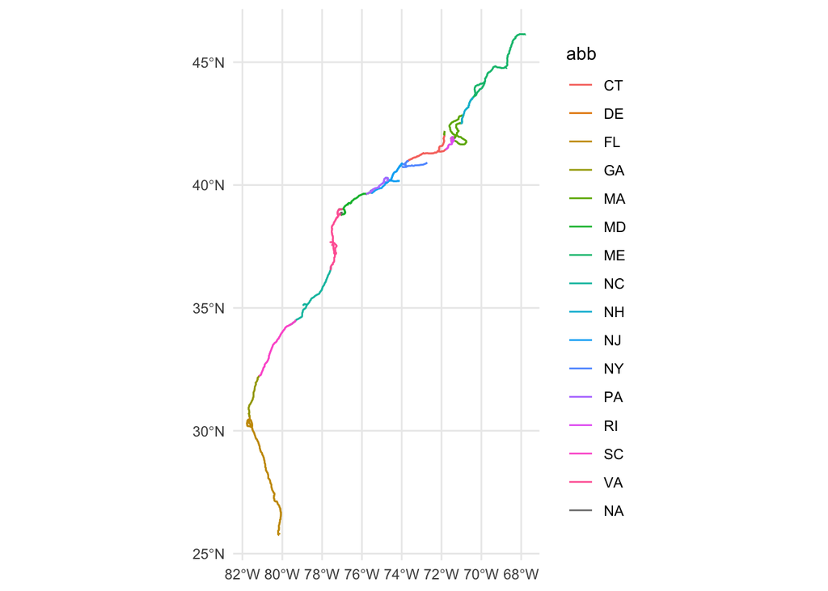

```r
hwy %>%
  spatial_join(state) %>%
  ggplot() +
    geom_sf(aes(color = abb))
```

Start by creating a data set called `hwy_with_state` that joins `hwy` to the `state` data.

```r
hwy_with_state <- hwy %>%
  spatial_join(state)
```

Now, we want to create a data set called `state_in_hwy` from a semi join of `state` with `hwy_with_state`. R won’t let us do this directly though because we are not allowed to do a semi join with two spatial datasets directly. Instead, we first need to create a non-spatial version of `hwy_with_state` with this code:

```r
hwy_with_state_tbl <- hwy_with_state %>%
  as_tibble() %>%
  select(-geometry)
```

Now, create `state_in_hwy` as a semi join between `state` and `hwy_with_state_tbl`:

```r
state_in_hwy <- state %>%
  semi_join(hwy_with_state_tbl, by = "state")
```

Now, create the desired plot using `hwy_with_state` and `state_in_hwy`. Take a moment to try to make the plot look nice.

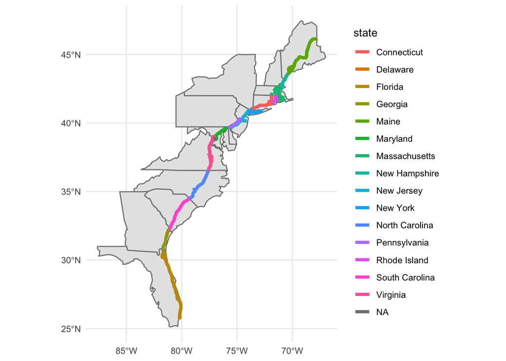

```r
hwy_with_state %>%
  ggplot() +
    geom_sf(data = state_in_hwy, color = "grey50", fill = "grey90") +
    geom_sf(aes(color = state), size = 1.5)
```